# Linear Modeling and Prediction for Movies

Wayne Yang (waynejeyang@gmail.com)

## Setup

Loading required packages and Data

### Load packages

```r
library(ggplot2)
library(dplyr)
library(statsr)
library(gridExtra)
```

### Load data

```r
load("~/Desktop/movies.Rdata")
```

## Part 1: Data

The given dataset has extracted movie information from IMDB and Rotten tomatoes. This dataset comprises of 651 randomly sample movies produced and released before 2016. The randomly sampled movies was obtained from the larger population pool of movies, thus we can attempt to generalise the sample to the larger population of movies.

This data sample is purely observational – therefore, it doesn’t involve an experimental set up with random assignment. Hence, we can infer only association and not causality.

## Part 2: Research question

For this project, we are attempting to determine whether a movie’s associated parameters are linked to the movie’s audience score on Rotten Tomatoes?

The parameters initially involved to predict audience score are: • Genre OK • Mpaa Rating • Rating on IMDB • Number of votes on IMDB • Critics Score • Whether or not the movie was nominated for a best picture Oscar • Whether or not one of the main actors in the movie ever won an Oscar • Whether or not one of the main actresses in the movie ever won an Oscar • Whether or not the director of the movie ever won an Oscar

Answering this research question would be of interest to media companies who stream movies and such. Hence, they can tailor their movie variety and selection to favour sales.

Note – I decided not to include the parameters of whether the movie was nominated for a best picture Oscar or won an Oscar. This is because the decision whether the movie is nominated or wins an Oscar happens a period of time after the audience score of the respective movie is given on Rotten Tomatoes. All other excluded variables weren’t included due to them being either redundant or not related to the research question.

## Part 3: Exploratory data analysis

First, the selection of the variables that will be used within the project were extracted from the larger movie data set. Below are the summary statistics of the subset.

```r
rsq <- select(movies, best_actor_win, best_actress_win, genre, mpaa_rating, audience_score, best_dir_win, imdb_rating, imdb_num_votes, critics_score)
summary(rsq)
```

```
##  best_actor_win best_actress_win                genre      mpaa_rating
##  no :558        no :579          Drama             :305   G      : 19
##  yes: 93        yes: 72          Comedy            : 87   NC-17  :  2
##                                  Action & Adventure: 65   PG     :118
##                                  Mystery & Suspense: 59   PG-13  :133
##                                  Documentary       : 52   R      :329
##                                  Horror            : 23   Unrated: 50
##                                  (Other)           : 60
##  audience_score  best_dir_win  imdb_rating    imdb_num_votes
##  Min.   :11.00   no :608      Min.   :1.900   Min.   :   180
##  1st Qu.:46.00   yes: 43      1st Qu.:5.900   1st Qu.:  4546
##  Median :65.00                Median :6.600   Median : 15116
##  Mean   :62.36                Mean   :6.493   Mean   : 57533
##  3rd Qu.:80.00                3rd Qu.:7.300   3rd Qu.: 58300
##  Max.   :97.00                Max.   :9.000   Max.   :893008
##
##  critics_score
##  Min.   :  1.00
##  1st Qu.: 33.00
##  Median : 61.00
##  Mean   : 57.69
##  3rd Qu.: 83.00
##  Max.   :100.00
##
```

```r
Figure1 <- ggplot(rsq, aes(x = rsq$genre, y = rsq$audience_score)) +
  geom_dotplot(binaxis = "y",stackdir = "center", binwidth = 1, alpha = 2/3) +
  theme(axis.text.x = element_text(angle = 45, hjust = 1)) +
  xlab("Movie Genre") +
  ylab("Audience Score")
```

```r
Figure2 <- ggplot(rsq, aes(x = rsq$mpaa_rating, y = rsq$audience_score)) +
  geom_boxplot() +
  theme(axis.text.x = element_text(angle = 45, hjust = 1)) +
  xlab("MPAA Rating") +
  ylab("Audience Score") +
  facet_grid(.~ rsq$best_dir_win)
```

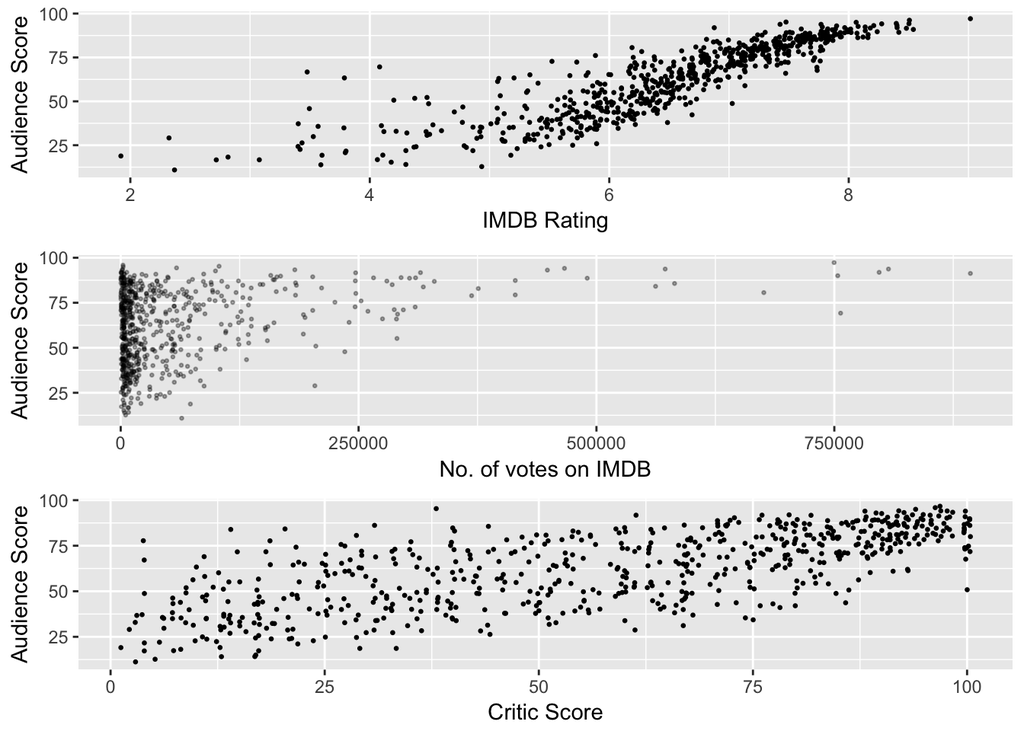

```r
Figure3 <-ggplot(rsq, aes(x = rsq$imdb_rating, y = rsq$audience_score)) +
  geom_jitter(size = 1/2) +
  xlab("IMDB Rating") +
  ylab("Audience Score")
Figure4 <- ggplot(rsq, aes(x = rsq$imdb_num_votes, y = rsq$audience_score)) +
  geom_jitter(size = 1/2, alpha = 1/3) +
  xlab("No. of votes on IMDB") +
  ylab("Audience Score")
Figure5 <- ggplot(rsq, aes(x = rsq$critics_score, y = rsq$audience_score)) +
  geom_jitter(size = 1/2) +
  xlab("Critic Score") +
  ylab("Audience Score")

grid.arrange(Figure3, Figure4, Figure5)
```

Figure 3,4 & 5. The above three figures are the numerical variables pitted up against audience score. We can visualise and grasp an initial understanding of the potential relationship between the variables.

## Part 4: Modeling

Diagnostics required for multiple linear regression include: • Near linear relationship between numerical explanatory variable and response variable • Normally distributed residuals • Constant variability of residuals • Independence of residuals (Independence of observations)

Numerical variables included within this project are IMDB rating, number of votes on IMDB, and critic score. Hence, these variables will be utilised as predictor variables for the purpose of this multiple linear regression model.

Note – We can assume independence of residuals based on the independence of observations from the randomly selected movies within the dataset.

```r
rsqmodel <-lm(audience_score ~., data = rsq)
summary(rsqmodel)
```

```
##
## Call:
## lm(formula = audience_score ~ ., data = rsq)
##
## Residuals:
##     Min      1Q  Median      3Q     Max
## -28.443  -6.636   0.517   5.742  49.704
##
## Coefficients:
##                                  Estimate Std. Error t value Pr(>|t|)
## (Intercept)                    -3.629e+01  4.165e+00  -8.714  < 2e-16 ***
## best_actor_winyes              -1.375e+00  1.140e+00  -1.206  0.22816
## best_actress_winyes            -1.983e+00  1.273e+00  -1.558  0.11977
## genreAnimation                  8.976e+00  3.834e+00   2.341  0.01955 *
## genreArt House & International  4.905e-01  3.001e+00   0.163  0.87021
## genreComedy                     2.582e+00  1.639e+00   1.575  0.11569
## genreDocumentary                1.457e+00  2.287e+00   0.637  0.52432
## genreDrama                      6.911e-01  1.451e+00   0.476  0.63392
## genreHorror                    -4.798e+00  2.447e+00  -1.960  0.05040 .
## genreMusical & Performing Arts  4.843e+00  3.194e+00   1.516  0.12999
## genreMystery & Suspense        -5.241e+00  1.848e+00  -2.835  0.00472 **
## genreOther                      1.579e+00  2.781e+00   0.568  0.57051
## genreScience Fiction & Fantasy -5.370e-01  3.512e+00  -0.153  0.87851
## mpaa_ratingNC-17               -3.655e+00  7.460e+00  -0.490  0.62434
## mpaa_ratingPG                   9.010e-01  2.706e+00   0.333  0.73926
## mpaa_ratingPG-13               -9.312e-01  2.775e+00  -0.336  0.73735
## mpaa_ratingR                   -4.108e-01  2.681e+00  -0.153  0.87826
## mpaa_ratingUnrated              3.279e-01  3.047e+00   0.108  0.91434
## best_dir_winyes                -1.524e+00  1.606e+00  -0.949  0.34323
## imdb_rating                     1.460e+01  6.113e-01  23.890  < 2e-16 ***
## imdb_num_votes                  5.676e-06  4.004e-06   1.418  0.15679
## critics_score                   6.659e-02  2.183e-02   3.050  0.00238 **
## ---
## Signif. codes:  0 '***' 0.001 '**' 0.01 '*' 0.05 '.' 0.1 ' ' 1
##
## Residual standard error: 9.82 on 629 degrees of freedom
## Multiple R-squared:  0.7718, Adjusted R-squared:  0.7642
## F-statistic: 101.3 on 21 and 629 DF,  p-value: < 2.2e-16
```

Above is the initial linear model with all the variables that were to be involved with the prediction.

```r
rsqmodelfinal <- lm(audience_score ~ imdb_rating + imdb_num_votes + critics_score, data = rsq)
summary(rsqmodelfinal)
```

```
##
## Call:
## lm(formula = audience_score ~ imdb_rating + imdb_num_votes +
##     critics_score, data = rsq)
##
## Residuals:
##     Min      1Q  Median      3Q     Max
## -26.620  -6.707   0.605   5.584  52.351
##
## Coefficients:
##                  Estimate Std. Error t value Pr(>|t|)
## (Intercept)    -3.672e+01  2.958e+00 -12.414   <2e-16 ***
## imdb_rating     1.459e+01  5.884e-01  24.794   <2e-16 ***
## imdb_num_votes  1.617e-06  3.749e-06   0.431   0.6663
## critics_score   7.385e-02  2.168e-02   3.406   0.0007 ***
## ---
## Signif. codes:  0 '***' 0.001 '**' 0.01 '*' 0.05 '.' 0.1 ' ' 1
##
## Residual standard error: 10.09 on 647 degrees of freedom
## Multiple R-squared:  0.7524, Adjusted R-squared:  0.7513
## F-statistic: 655.5 on 3 and 647 DF,  p-value: < 2.2e-16
```

Due to the diagnostics required for multiple linear regression, I removed the categorical variables. Therefore, the remaining numerical variables (IMDB Rating, IMDB Number of Votes, Critic Score and Audience Score) will be used to form a regression model.

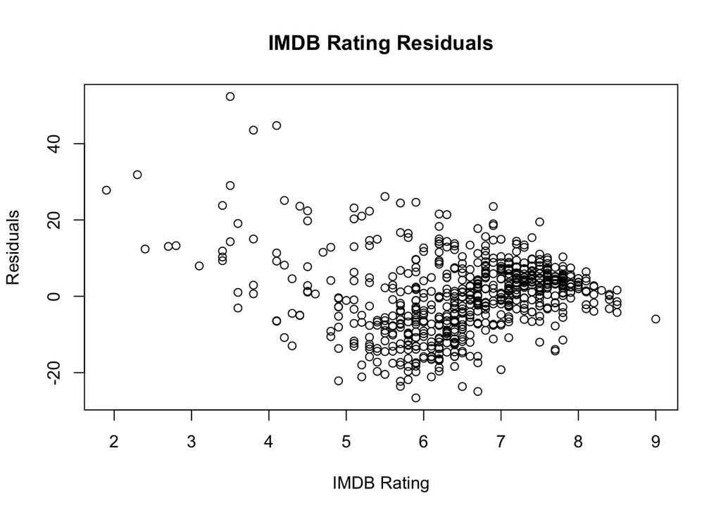

```r
Plot1 <- plot(rsqmodelfinal$residuals ~ rsq$imdb_rating, xlab = "IMDB Rating", ylab = "Residuals", main = "IMDB Rating Residuals")
```

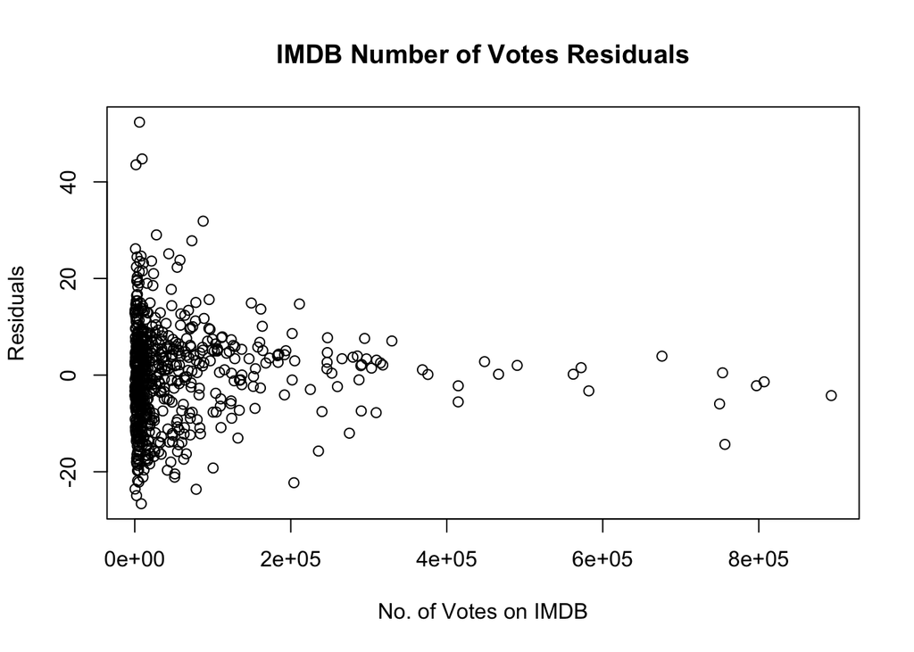

```r
Plot2 <- plot(rsqmodelfinal$residuals ~ rsq$imdb_num_votes, xlab = "No. of Votes on IMDB", ylab = "Residuals", main = "IMDB Number of Votes Residuals")
```

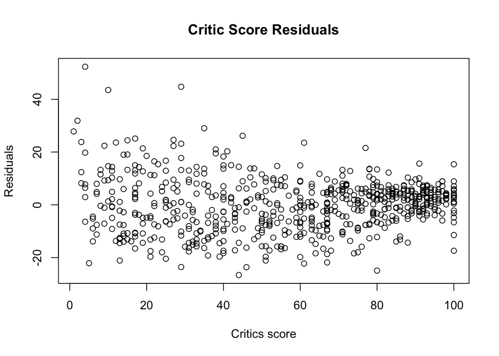

```r
Plot3 <- plot(rsqmodelfinal$residuals ~ rsq$critics_score, xlab = "Critics score", ylab = "Residuals", main = "Critic Score Residuals")
```

The 3 residual plots above show the scattering around 0 for the variables of IMDB Rating, IMDB No. of Votes and Critic Score respectively.

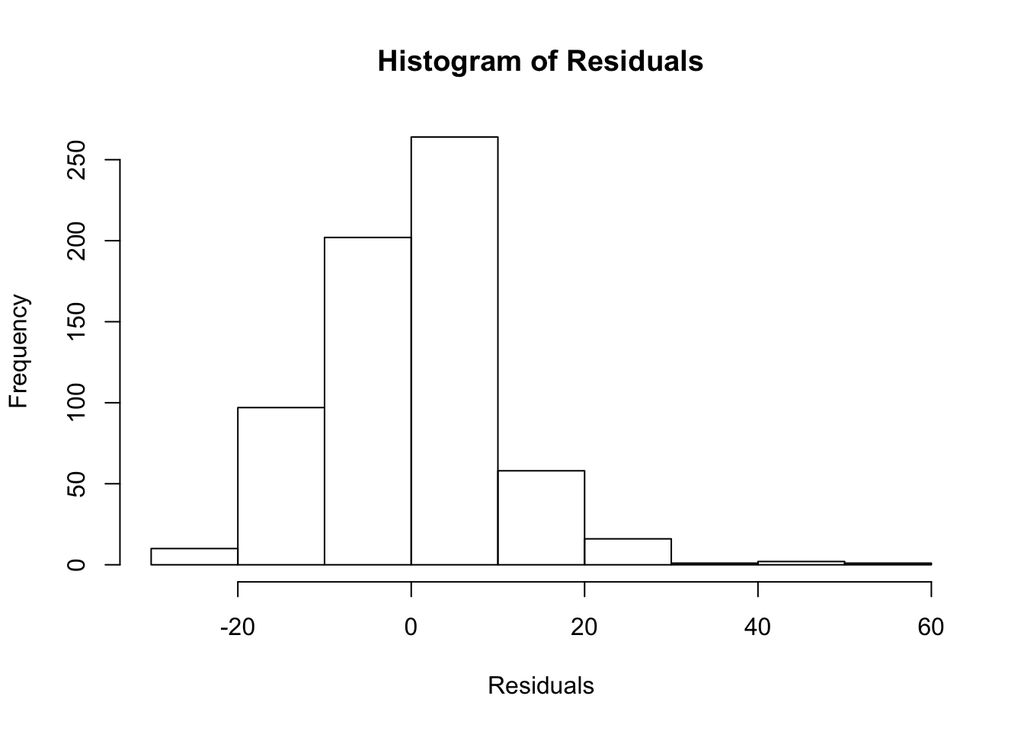

```r
hist(rsqmodelfinal$residuals, xlab = "Residuals", main = "Histogram of Residuals")
```

The histogram of the residuals above show slight skewness to the right.

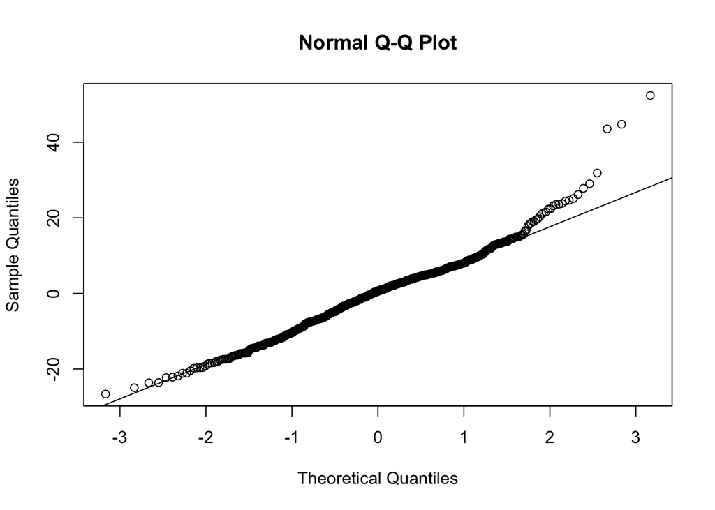

```r
qqnorm(rsqmodelfinal$residuals)
qqline(rsqmodelfinal$residuals)
```

The Q-Q plot above displays some skewness towards the tails (2,3 theoretical quantiles from 0 in both directions).

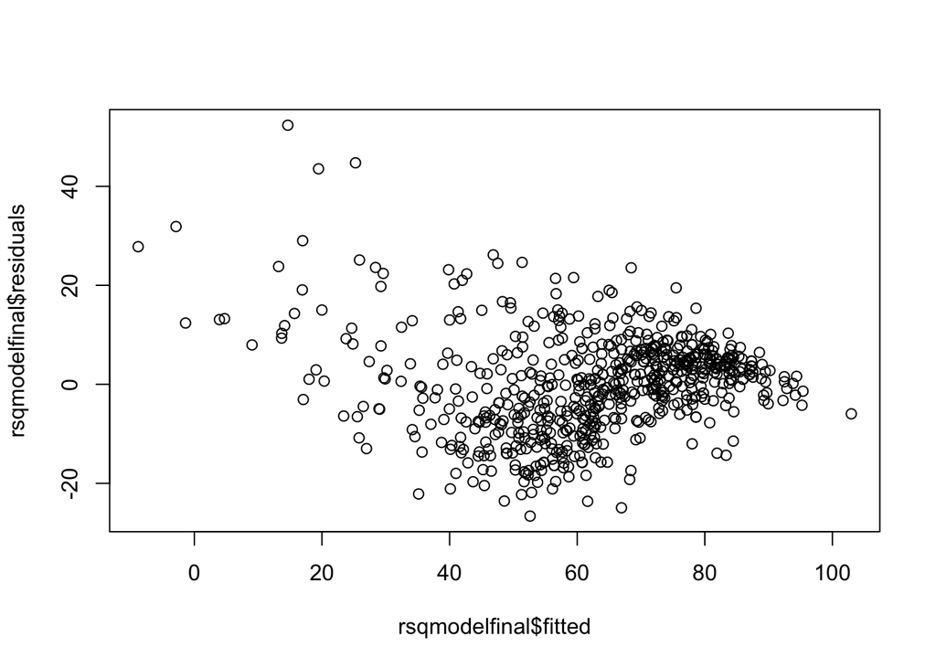

```r
plot(rsqmodelfinal$fitted, rsqmodelfinal$residuals)
```

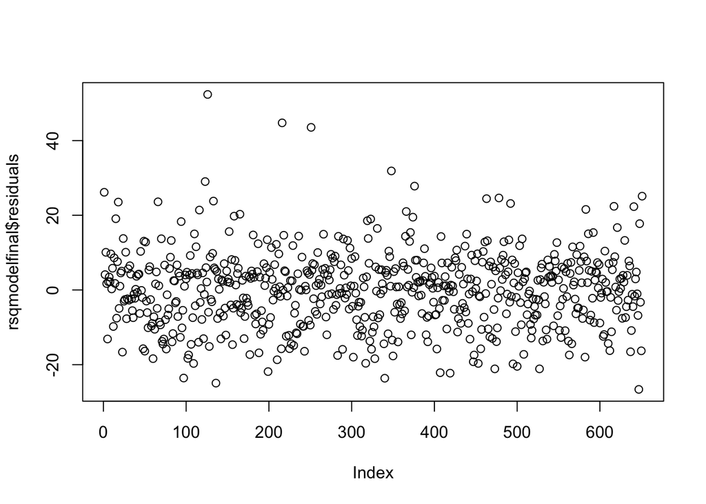

```r
plot(rsqmodelfinal$residuals)
```

The residuals plot above show approximate homoscedasticity which assumes that the variance around the regression line (0,0) is the same for all values of the predictor variables. There does seem to be some abnormal values, however not many.

## Part 5: Prediction

Lastly, the model is going to be used to predict the audience score on Rotten Tomatoes of the movie “Dead Pool” (2016). The parameters used to predict the audience score will be the explanatory numerical parameters mentioned above.

```r
deadpool <- data.frame(imdb_rating = 8,
                       imdb_num_votes = 679872,
                       critics_score = 84)

deadpool_prediction <- predict(rsqmodelfinal, deadpool, interval = "confidence")
deadpool_prediction
```

```
##        fit      lwr      upr
## 1 87.29615 82.89774 91.69456
```